# Trabajo1_R

Rodrigo Reyes

2023-05-20

Identificar indicadores predictivos de performance sanitario para salmones en cultivo. Con el fin de mitigar la presentación de brotes de enfermedad. Las variables en estudio evaluarán el desempeño de 3 dietas suministradas durante el ciclo productivo de mar (2021-2022) de Salmon del Atlantico en un centro de cultivo de la XI Región. Estas, consideran Mortalidad total (%) y SFR (%) diaria desde 08/08/2021 al 11/09/2022. El número de observaciones son 2.880 y las variables serán 3 (Dieta, Mortalidad total (%) y SFR (%)) y quizá se explore al nivel de jaula.

# Importa librerías de interés.

Se instalaron paquetes readxl, ggplot2, dyplr, gridExtra, grid, kableExtra, tidyverse.

```r
Trabajo_personal_R <- read_excel("Trabajo personal R.xlsx")
```

# Evaluación de variables

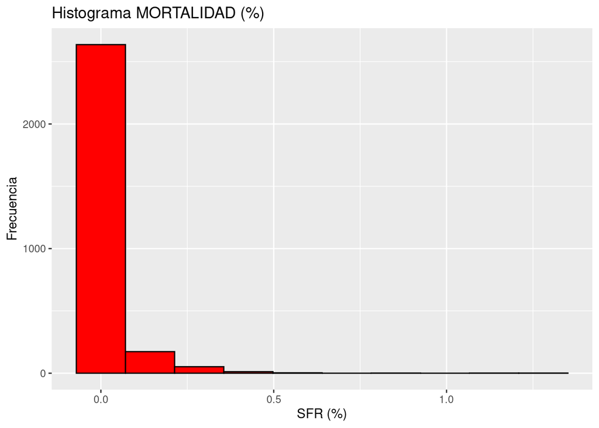

```r
ggplot(Trabajo_personal_R, aes(MO))+
geom_histogram(color="black", fill="red", bins = 10)+
labs(title="Histograma MORTALIDAD (%)", x="SFR (%)",
y="Frecuencia") + theme_gray()
```

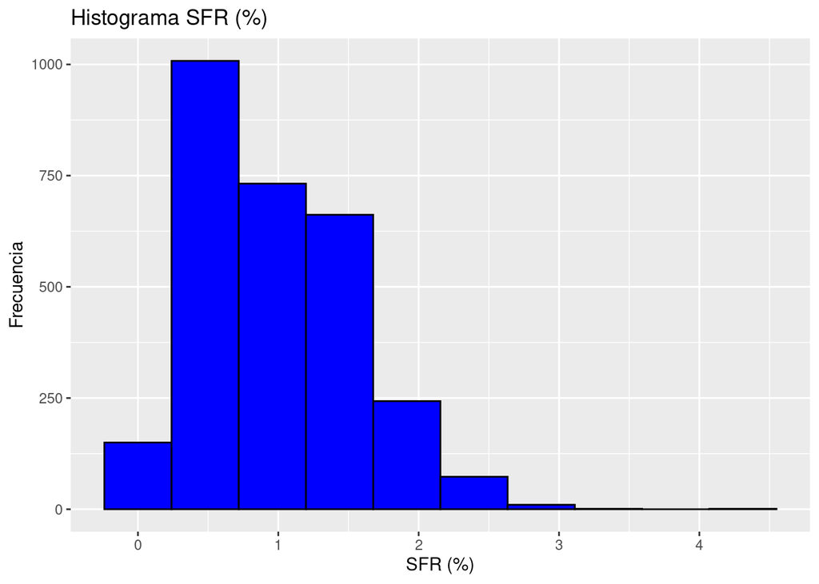

```r
ggplot(Trabajo_personal_R, aes(SFR))+
geom_histogram(color="black", fill="blue", bins = 10)+
labs(title="Histograma SFR (%)", x="SFR (%)",
y="Frecuencia") + theme_gray()
```

# Balance de datos

En base a este resultado, se evaluarán Mortalidad y SFR por Jaula. Dieta Control: Jaulas 105 y 106. Dieta Desafío: Jaulas 107 y 108.

```r
Trabajo_personal_R <- read_excel("Trabajo personal R.xlsx")
table(Trabajo_personal_R$DIETA,Trabajo_personal_R$Jaula)
```

```
##
##           101 102 103 104 105 106 107 108
##   CONTROL   0   0   0   0 360 387   0   0
##   DESAFIO   0   0   0   0   0   0 383 382
##   NORMAL  315 328 348 377   0   0   0   0
```

# Relación entre variables cuantitativas

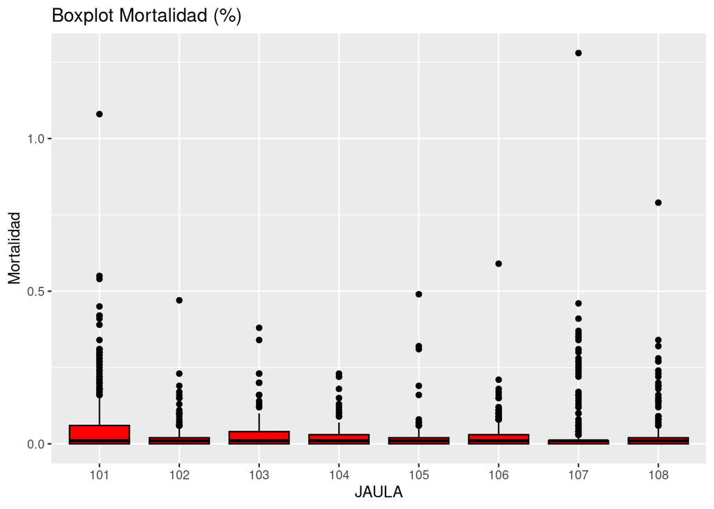

```r
ggplot(Trabajo_personal_R, aes(x=Jaula, y=MO))+
geom_boxplot(color="black", fill="red")+
labs(title="Boxplot Mortalidad (%)", x="JAULA", y="Mortalidad") + theme_gray()
```

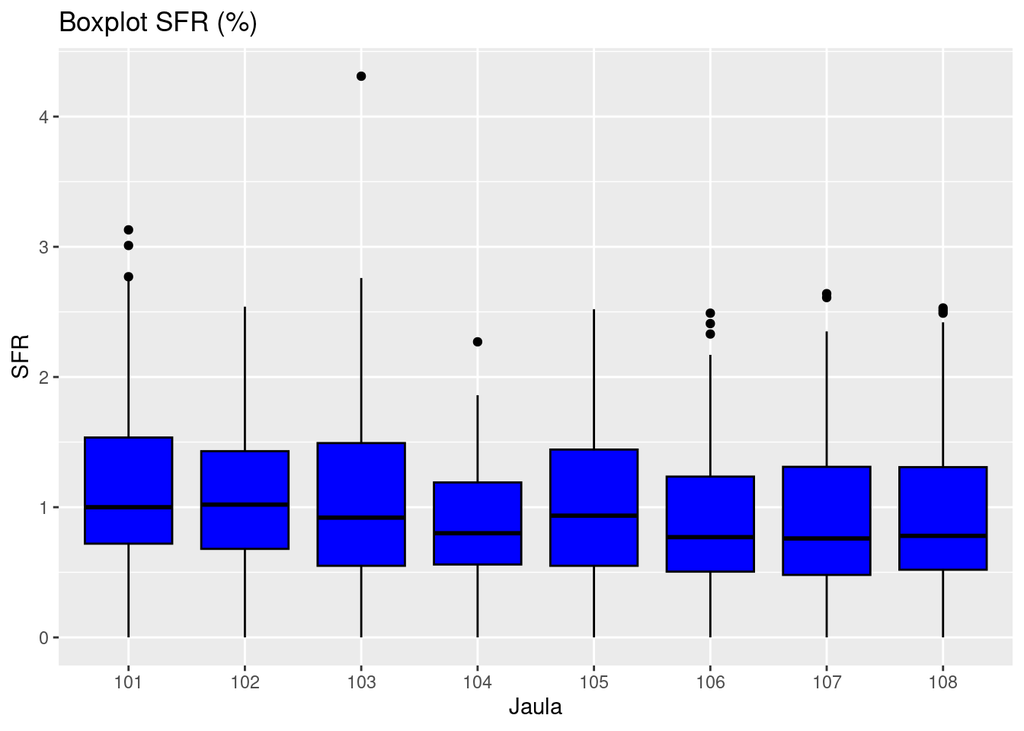

```r
ggplot(Trabajo_personal_R, aes(x=Jaula, y=SFR))+
geom_boxplot(color="black", fill="blue", bins = 10)+
labs(title="Boxplot SFR (%)", x="Jaula", y="SFR") + theme_gray()
```

# Revisión estructura de la información.

Se evidencia un gran número de observaciones NA, las cuales se proceden a omitir, sin embargo, reduce mucho el número de observaciones. Dejando solo los días con tratamiento con FFC.

```r
str(Trabajo_personal_R)
```

```
## tibble [2,880 × 33] (S3: tbl_df/tbl/data.frame)
##  $ Jaula                          : chr [1:2880] "101" "102" "101" "102" ...
##  $ DIETA                          : chr [1:2880] "NORMAL" "NORMAL" "NORMAL" "NORMAL" ...
##  $ TTO                            : chr [1:2880] NA NA NA NA ...
##  $ Fecha                          : POSIXct[1:2880], format: "2021-08-08" "2021-08-08" ...
##  $ Numero inicial                 : num [1:2880] 100000 100000 98924 99530 98899 ...
##  $ PESO gr                        : num [1:2880] 120 120 121 121 123 123 189 124 125 189 ...
##  $ ALIMENTO ENTREGADO kg          : logi [1:2880] NA NA NA NA NA NA ...
##  $ SFR                            : num [1:2880] 0 0 0.63 0.74 0.92 0.96 0 1.11 1.03 0 ...
##  $ MO                             : num [1:2880] 1.08 0.47 0.03 0.01 0.02 0.01 0 0.02 0.02 0.04 ...
##  $ MO SRS                         : num [1:2880] 0 0 0 0 0 0 0 0 0 0 ...
##  $ MO numero                      : num [1:2880] 1076 470 25 12 22 ...
##  $ Inmersion                      : num [1:2880] 0 0 0 0 0 0 0 0 0 0 ...
##  $ BKD                            : num [1:2880] 0 0 0 0 0 0 0 0 0 0 ...
##  $ Bloat                          : num [1:2880] 0 0 0 0 0 0 0 0 0 0 ...
```

[output cut: 19 more lines]

```r
summary(Trabajo_personal_R)
```

```
##     Jaula              DIETA               TTO
##  Length:2880        Length:2880        Length:2880
##  Class :character   Class :character   Class :character
##  Mode  :character   Mode  :character   Mode  :character
##
##
##
##      Fecha                     Numero inicial      PESO gr
##  Min.   :2021-08-08 00:00:00   Min.   :  3015   Min.   : 120
##  1st Qu.:2021-11-14 00:00:00   1st Qu.: 93071   1st Qu.: 659
##  Median :2022-02-12 00:00:00   Median : 97644   Median :2136
##  Mean   :2022-02-13 03:24:00   Mean   : 93873   Mean   :2381
##  3rd Qu.:2022-05-13 00:00:00   3rd Qu.: 98794   3rd Qu.:3908
##  Max.   :2022-09-11 00:00:00   Max.   :100000   Max.   :5986
##  ALIMENTO ENTREGADO kg      SFR               MO              MO SRS
##  Mode:logical          Min.   :0.0000   Min.   :0.00000   Min.   :0.000000
##  TRUE:122              1st Qu.:0.5500   1st Qu.:0.00000   1st Qu.:0.000000
##  NA's:2758             Median :0.8800   Median :0.01000   Median :0.000000
##                        Mean   :0.9762   Mean   :0.02764   Mean   :0.008695
##                        3rd Qu.:1.3700   3rd Qu.:0.02000   3rd Qu.:0.003329
##                        Max.   :4.3100   Max.   :1.28000   Max.   :0.547182
##    MO numero         Inmersion             BKD              Bloat
##  Min.   :   0.00   Min.   :  0.0000   Min.   : 0.0000   Min.   :0.000000
##  1st Qu.:   3.00   1st Qu.:  0.0000   1st Qu.: 0.0000   1st Qu.:0.000000
##  Median :   7.00   Median :  0.0000   Median : 0.0000   Median :0.000000
##  Mean   :  24.71   Mean   :  0.3847   Mean   : 0.2476   Mean   :0.001389
##  3rd Qu.:  22.00   3rd Qu.:  0.0000   3rd Qu.: 0.0000   3rd Qu.:0.000000
##  Max.   :1235.00   Max.   :550.0000   Max.   :25.0000   Max.   :1.000000
##    D_Mecanico      D_Mecanico Transporte    Deforme         Desadaptado
##  Min.   :  0.000   Min.   :  0.0000      Min.   : 0.0000   Min.   : 0.00000
##  1st Qu.:  0.000   1st Qu.:  0.0000      1st Qu.: 0.0000   1st Qu.: 0.00000
##  Median :  2.000   Median :  0.0000      Median : 0.0000   Median : 0.00000
##  Mean   :  3.955   Mean   :  0.4052      Mean   : 0.4681   Mean   : 0.04792
##  3rd Qu.:  4.000   3rd Qu.:  0.0000      3rd Qu.: 0.0000   3rd Qu.: 0.00000
##  Max.   :342.000   Max.   :280.0000      Max.   :18.0000   Max.   :13.00000
##  Eliminacion Productiva Deformes      HSMI               Lobo
##  Min.   : 0.00000                Min.   :   0.000   Min.   :  0.000
##  1st Qu.: 0.00000                1st Qu.:   0.000   1st Qu.:  0.000
##  Median : 0.00000                Median :   0.000   Median :  0.000
##  Mean   : 0.09861                Mean   :   4.065   Mean   :  0.301
```

[output cut: 8 more lines]

```
##  Max.   :7.00000   Max.   :115.0000   Max.   :10.00000   Max.   :4.000000
##      Otros             Pajaro             PGD            Rezagado
##  Min.   :  0.000   Min.   : 0.0000   Min.   : 0.000   Min.   : 0.000
##  1st Qu.:  0.000   1st Qu.: 0.0000   1st Qu.: 0.000   1st Qu.: 0.000
##  Median :  0.000   Median : 0.0000   Median : 0.000   Median : 0.000
##  Mean   :  1.916   Mean   : 0.1174   Mean   : 0.551   Mean   : 1.593
##  3rd Qu.:  0.000   3rd Qu.: 0.0000   3rd Qu.: 0.000   3rd Qu.: 2.000
##  Max.   :361.000   Max.   :21.0000   Max.   :81.000   Max.   :36.000
##  Sin Causa Aparente      SRS          Tenacibaculosis    Transporte
##  Min.   : 0.0000    Min.   :  0.000   Min.   : 0.000   Min.   :   0.0000
##  1st Qu.: 0.0000    1st Qu.:  0.000   1st Qu.: 0.000   1st Qu.:   0.0000
##  Median : 0.0000    Median :  0.000   Median : 0.000   Median :   0.0000
##  Mean   : 0.6618    Mean   :  7.669   Mean   : 1.053   Mean   :   0.5368
##  3rd Qu.: 1.0000    3rd Qu.:  3.000   3rd Qu.: 0.000   3rd Qu.:   0.0000
##  Max.   :20.0000    Max.   :509.000   Max.   :54.000   Max.   :1076.0000
```

```r
dim(Trabajo_personal_R)
```

```
## [1] 2880   33
```

```r
Trabajo_personal_R_new <- na.omit(Trabajo_personal_R)
```

```r
dim(Trabajo_personal_R_new)
```

```
## [1] 14 33
```

# Analisis exploratorio de datos

Evaluando el comportamiento de la mortalidad y SFR durante el ciclo productivo, Se aprecia un quiebre en la alimentación en Enero de 2022, lo cual no va correlacionado con el estado sanitario. Sin embargo, podría ser un predictor del posterior desmedro en condición sanitaria (abril), también habría que descartar un aumento en la temperatura del agua y aumento en el tamaño de peces, lo cual hace consuman un menor % de PC.

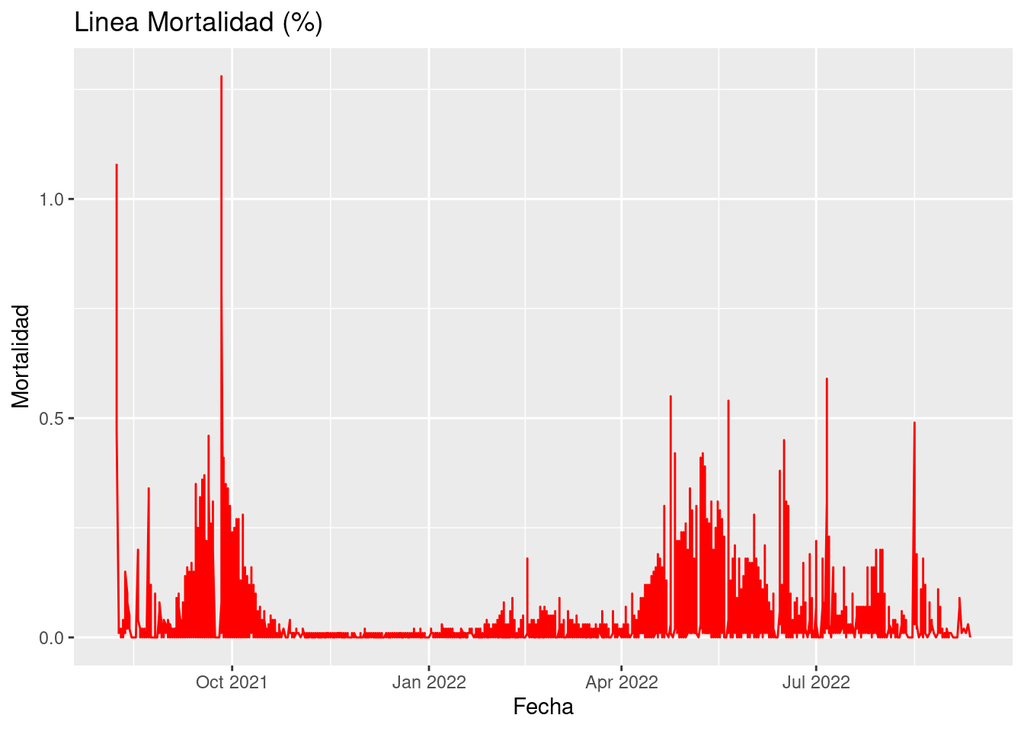

```r
ggplot(Trabajo_personal_R, aes(x=Fecha, y=MO))+
geom_line(color="red")+
labs(title="Linea Mortalidad (%)", x="Fecha", y="Mortalidad") + theme_gray()
```

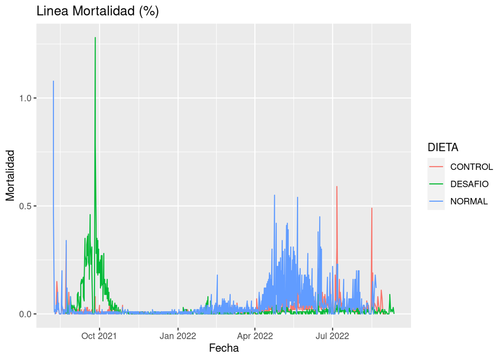

```r
ggplot(Trabajo_personal_R, aes(x=Fecha, y=MO, group = DIETA, colour = DIETA))+
geom_line()+
labs(title="Linea Mortalidad (%)", x="Fecha", y="Mortalidad") +
theme_gray()
```

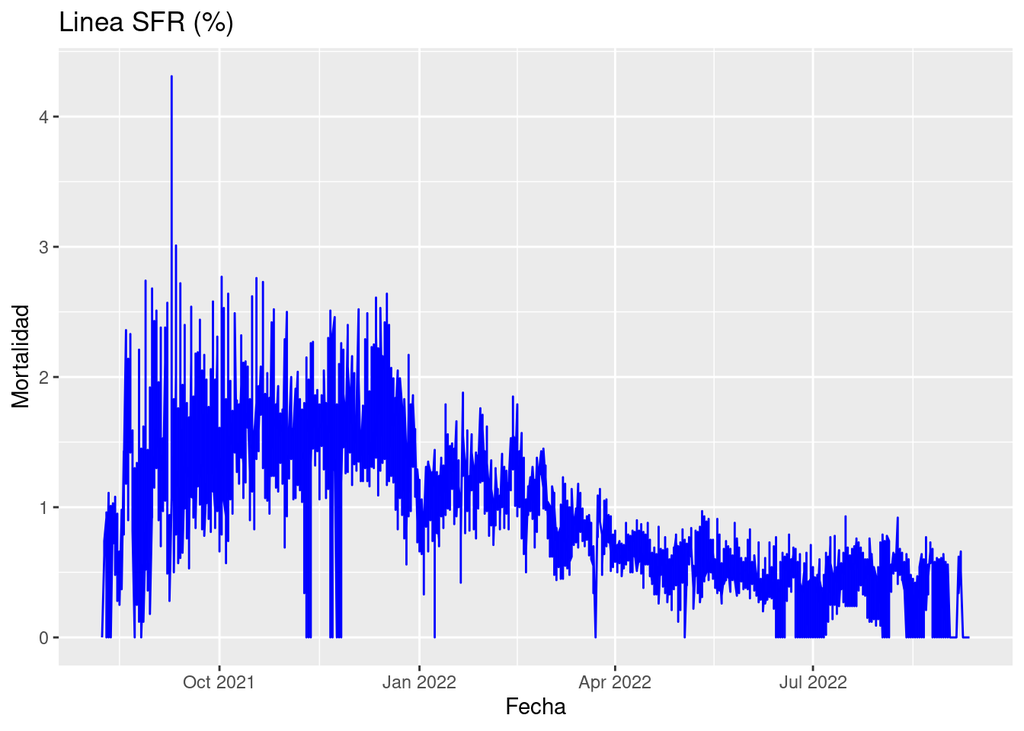

```r
ggplot(Trabajo_personal_R, aes(x=Fecha, y=SFR))+
geom_line(color="blue", bins = 10)+
labs(title="Linea SFR (%)", x="Fecha", y="Mortalidad") + theme_gray()
```

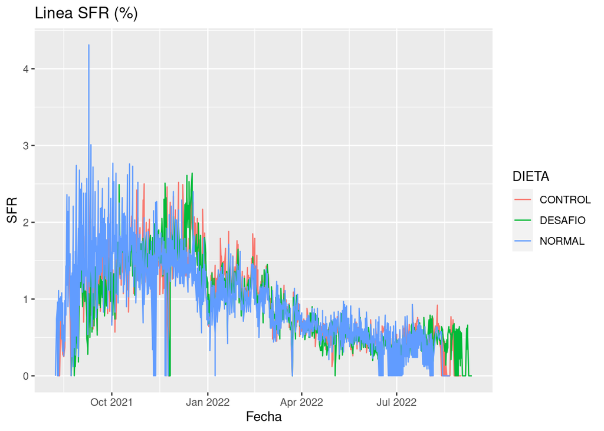

```r
ggplot(Trabajo_personal_R, aes(x=Fecha, y=SFR, group = DIETA, colour = DIETA))+
geom_line()+
labs(title="Linea SFR (%)", x="Fecha", y="SFR") +
theme_gray()
```

# Resumen de datos

Se evalua desempeño promedio, en mortalidad y SFR durante todo el ciclo productivo de mar, por jaula.

```r
Trabajo_personal_R %>%
  group_by(Jaula, DIETA) %>%
  summarize(mean(MO), mean(SFR))
```

```
## # A tibble: 8 × 4
## # Groups:   Jaula [8]
##   Jaula DIETA   `mean(MO)` `mean(SFR)`
##   <chr> <chr>        <dbl>       <dbl>
## 1 101   NORMAL      0.0618       1.15
## 2 102   NORMAL      0.0195       1.08
## 3 103   NORMAL      0.0284       1.03
## 4 104   NORMAL      0.0207       0.867
## 5 105   CONTROL     0.0164       1.03
## 6 106   CONTROL     0.0249       0.871
## 7 107   DESAFIO     0.0292       0.903
## 8 108   DESAFIO     0.0246       0.921
```

```r
res.aov <- lm(SFR ~ DIETA, data = Trabajo_personal_R)
anova(res.aov)
```

```
## Analysis of Variance Table
##
## Response: SFR
##             Df Sum Sq Mean Sq F value    Pr(>F)
## DIETA        2   7.31  3.6563  11.892 7.187e-06 ***
## Residuals 2877 884.56  0.3075
## ---
## Signif. codes:  0 '***' 0.001 '**' 0.01 '*' 0.05 '.' 0.1 ' ' 1
```